# MScFE 620 Derivative Pricing - Group Work Project

# Group 17185

**Base Case Parameters:**

- $S_0 = 100$
- $K = 100$
- $r = 5\%$
- $T = 3\text{ months} = 0.25\text{ years}$
- $\sigma = 20\%$

### Step 1 - Group Theory: Put-Call Parity (Questions 1–3)

#### Question 1: Does put-call parity apply for European options? Why or why not?

**Yes, put-call parity holds strictly for European options on non-dividend-paying assets.**

- **Replication Portfolios at $t=0$:**
  - **Portfolio A:** One European call ($C$) + Cash equal to present value of strike ($K e^{-rT}$).
  - **Portfolio B:** One European put ($P$) + One share of underlying stock ($S_0$).
- **Terminal Payoff at $t=T$:**
  - If $S_T \ge K$: Portfolio A delivers $(S_T - K) + K = S_T$; Portfolio B delivers $0 + S_T = S_T$.
  - If $S_T < K$: Portfolio A delivers $0 + K = K$; Portfolio B delivers $(K - S_T) + S_T = K$.
- In all states of the binomial lattice, both portfolios yield identical cash flows $\max(S_T, K)$ at maturity. By the **Law of One Price (no-arbitrage)**, their values at time 0 must be equal:

$$C + K e^{-rT} = P + S_0$$

#### Question 2: Rewriting Put-Call Parity

- **Solving for European Call Price ($C$):** $$C = P + S_0 - K e^{-rT}$$
- **Solving for European Put Price ($P$):** $$P = C + K e^{-rT} - S_0$$

#### Question 3: Does put-call parity apply for American options? Why or why not?

**Exact put-call parity does NOT hold for American options; it is replaced by an inequality bounding condition.**

- **Early Exercise Effect:** American options can be exercised at any time $t \le T$. This extra optionality ensures $C_{Amer} \ge C_{Euro}$ and $P_{Amer} \ge P_{Euro}$.
- For non-dividend assets, early exercise of a call is never optimal ($C_{Amer} = C_{Euro}$), but early exercise of an American put can be optimal ($P_{Amer} > P_{Euro}$) to immediately realize strike cash $K$ and earn interest.
- Because early exercise destroys static replication, strict equality fails, resulting in the bounds:

$$S_0 - K \le C_{Amer} - P_{Amer} \le S_0 - K e^{-rT}$$

```python
import numpy as np
import pandas as pd
from scipy.stats import norm

# Global Base Case
S0 = 100.0
K_atm = 100.0
r = 0.05
T = 0.25
sigma = 0.20

np.random.seed(42)  # reproducibility for every Monte-Carlo exercise below
pd.set_option('display.float_format', lambda x: f'{x:,.4f}')
```

#### Question 4: European Options via Binomial Tree (CRR Model)

- **Step count:** $N = 500$ steps, chosen the same way as Question 7 — discretisation error versus the Black-Scholes closed form drops below $0.005$ with sub-second execution (see the convergence check below).
- **Process:** Build the CRR tree,

  $$ u=e^{\sigma\sqrt{\Delta t}}, \qquad d=\frac{1}{u}, \qquad p=\frac{e^{r\Delta t}-d}{u-d}, $$

  compute the terminal payoffs

  $$ \max(S_T-K_{\text{atm}},0) $$

  for the call and

  $$ \max(K_{\text{atm}}-S_T,0) $$

  for the put, then fold the tree backward one step at a time using the discounted risk-neutral expectation

  $$ e^{-r\Delta t}\left[pV_u+(1-p)V_d\right]. $$

  No early-exercise check is required because these are European options.

```python
def binomial_tree_european(S0, K, r, sigma, T, N=500, option_type='call'):
    """
    Price a European option on a CRR binomial tree.
    Returns (price, delta_time0), where delta_time0 is the tree-implied
    Delta computed from the two nodes reached after the first step.
    """
    dt = T / N
    u = np.exp(sigma * np.sqrt(dt))
    d = 1.0 / u
    p = (np.exp(r * dt) - d) / (u - d)
    df = np.exp(-r * dt)

    ST = S0 * (u ** np.arange(N, -1, -1)) * (d ** np.arange(0, N + 1, 1))
    values = np.maximum(ST - K, 0) if option_type.lower() == 'call' else np.maximum(K - ST, 0)

    values_after_step1 = None
    for i in range(N - 1, -1, -1):
        values = df * (p * values[:-1] + (1 - p) * values[1:])
        if i == 1:
            values_after_step1 = values.copy()   # [up node, down node]

    price = values[0]
    Vu, Vd = values_after_step1[0], values_after_step1[1]
    Su, Sd = S0 * u, S0 * d
    delta0 = (Vu - Vd) / (Su - Sd)
    return price, delta0


def bs_price(S0, K, r, sigma, T, option_type='call'):
    """Black-Scholes closed-form price, used only as a sanity check."""
    d1 = (np.log(S0 / K) + (r + 0.5 * sigma ** 2) * T) / (sigma * np.sqrt(T))
    d2 = d1 - sigma * np.sqrt(T)
    if option_type == 'call':
        return S0 * norm.cdf(d1) - K * np.exp(-r * T) * norm.cdf(d2)
    else:
        return K * np.exp(-r * T) * norm.cdf(-d2) - S0 * norm.cdf(-d1)
```

```python
# Convergence check supporting the N=500 step-count choice
step_choices = [10, 25, 50, 100, 200, 500, 1000]
rows = []
for n in step_choices:
    c, _ = binomial_tree_european(S0, K_atm, r, sigma, T, N=n, option_type='call')
    rows.append({"N (steps)": n, "Tree Call Price": round(c, 4)})
conv_df = pd.DataFrame(rows)
conv_df["BS Call Price"] = round(bs_price(S0, K_atm, r, sigma, T, 'call'), 4)
conv_df["Abs. Diff vs BS"] = (conv_df["Tree Call Price"] - conv_df["BS Call Price"]).abs().round(4)
conv_df
```

|  | N (steps) | Tree Call Price | BS Call Price | Abs. Diff vs BS |
| --- | --- | --- | --- | --- |
| 0 | 10 | 4.5166 | 4.6150 | 0.0984 |
| 1 | 25 | 4.6538 | 4.6150 | 0.0388 |
| 2 | 50 | 4.5951 | 4.6150 | 0.0199 |
| 3 | 100 | 4.6050 | 4.6150 | 0.0100 |
| 4 | 200 | 4.6100 | 4.6150 | 0.0050 |
| 5 | 500 | 4.6130 | 4.6150 | 0.0020 |
| 6 | 1000 | 4.6140 | 4.6150 | 0.0010 |

```python
N = 500  # chosen step count for all binomial-tree pricing below

call_price, call_delta0 = binomial_tree_european(S0, K_atm, r, sigma, T, N=N, option_type='call')
put_price,  put_delta0  = binomial_tree_european(S0, K_atm, r, sigma, T, N=N, option_type='put')

q4_table = pd.DataFrame({
    "Option": ["European Call", "European Put"],
    "Price ($)": [round(call_price, 2), round(put_price, 2)]
})
q4_table
```

|  | Option | Price ($) |
| --- | --- | --- |
| 0 | European Call | 4.6100 |
| 1 | European Put | 3.3700 |

**Process, in words (Q4b).** The tree discretises the option's remaining life $T$ into $N=500$ equal sub-intervals of length $\Delta t = T/N$. From $S_0$ it builds forward to all $N+1$ possible terminal stock prices at maturity, where the payoff is known exactly. It is then folded backward one step at a time: at every node the value is the risk-neutral expectation of its two successor nodes, discounted one period at $r$. Repeating this back to the root gives today's price. $N=500$ was chosen because the price series above stabilises to the cent and matches the Black-Scholes benchmark to within a fraction of a cent, while still running instantly.

#### Question 5: Delta of the European Call and Put at $t=0$

- **Approach:** read Delta off the tree from the two nodes reached after the first step: $\Delta_0 = \dfrac{V_u - V_d}{S_0 u - S_0 d}$, which converges to the Black-Scholes Delta as $N$ grows.

```python
q5_table = pd.DataFrame({
    "Option": ["European Call", "European Put"],
    "Delta (t=0)": [round(call_delta0, 4), round(put_delta0, 4)]
})
q5_table
```

|  | Option | Delta (t=0) |
| --- | --- | --- |
| 0 | European Call | 0.5694 |
| 1 | European Put | -0.4306 |

**(a) Comparison.** The call Delta is positive (≈ +0.57) and the put Delta is negative (≈ −0.43); they satisfy put-call parity exactly: $\Delta_{call} - \Delta_{put} = 1$, since $\partial(C-P)/\partial S = \partial S/\partial S = 1$.

**(b) Sign and interpretation.** Delta proxies the option's instantaneous sensitivity to the underlying — equivalently, the hedge ratio (shares of underlying needed to hedge one option), and it can loosely be read as a risk-neutral probability of finishing in-the-money. A call gains value when the stock rises, so its Delta is positive (0 to 1); a put gains value when the stock falls, so its Delta is negative (−1 to 0). This option is ATM, so both Deltas are of similar magnitude around 0.5 in absolute value; the call is slightly above 0.5 because the positive drift $r=5\%$ over the 3-month horizon pushes the risk-neutral distribution of $S_T$ slightly above $K_{atm}$, making the call marginally more likely to finish in-the-money than the put.

#### Question 6: Vega — Repricing for a +5% Volatility Shock (20% → 25%)

- **Approach:** reprice the same $N=500$-step tree with $\sigma$ bumped from 20% to 25%, holding $S_0$, $K_{atm}$, $r$ and $T$ fixed, and read Vega off the change in price.

```python
sigma_up = 0.25  # 20% + 5%
N = 500
call_price_up, _ = binomial_tree_european(S0, K_atm, r, sigma_up, T, N=N, option_type='call')
put_price_up,  _ = binomial_tree_european(S0, K_atm, r, sigma_up, T, N=N, option_type='put')

q6_table = pd.DataFrame({
    "Option": ["European Call", "European Put"],
    "Price at sigma=20%": [round(call_price, 2), round(put_price, 2)],
    "Price at sigma=25%": [round(call_price_up, 2), round(put_price_up, 2)],
    "Price Change (Vega proxy)": [round(call_price_up - call_price, 2),
                                   round(put_price_up - put_price, 2)]
})
q6_table
```

|  | Option | Price at sigma=20% | Price at sigma=25% | Price Change (Vega proxy) |
| --- | --- | --- | --- | --- |
| 0 | European Call | 4.6100 | 5.6000 | 0.9800 |
| 1 | European Put | 3.3700 | 4.3500 | 0.9800 |

**Comment.** Both the call and the put get more expensive as volatility rises — higher volatility widens the distribution of terminal stock prices, raising optionality value on both sides without adding downside (loss is capped at the premium).

The price increase is (to within rounding) **identical for the call and the put**. This is not a coincidence: put-call parity gives $C - P = S_0 - K_{atm} e^{-rT}$, and the right-hand side does not depend on $\sigma$ at all. Differentiating with respect to $\sigma$ gives $\partial C/\partial \sigma = \partial P/\partial \sigma$, i.e. **Vega$_{call}$ = Vega$_{put}$** for European options sharing the same strike and maturity — exactly what the matching price changes above show numerically.

### Step 1: Lattice Pricing, Parity and Greeks (American & Trinomial Trees)

#### Question 7: American Options via Binomial Tree (CRR Model)

- **Step count:** $N=500$ steps chosen for discretization error $< \$0.005$ with sub-second execution.
- **Process:** Backward induction comparing early exercise intrinsic value $\max(S_t-K, 0)$ or $\max(K-S_t, 0)$ with continuation value $e^{-r \Delta t}[p V_{u} + (1-p)V_{d}]$.

```python
def binomial_tree_american(S0, K, r, sigma, T, N=500, option_type='call'):
    dt = T / N
    u = np.exp(sigma * np.sqrt(dt))
    d = 1.0 / u
    p = (np.exp(r * dt) - d) / (u - d)
    df = np.exp(-r * dt)

    ST = S0 * (u ** np.arange(N, -1, -1)) * (d ** np.arange(0, N + 1, 1))
    values = np.maximum(ST - K, 0) if option_type.lower() == 'call' else np.maximum(K - ST, 0)

    for i in range(N - 1, -1, -1):
        ST = S0 * (u ** np.arange(i, -1, -1)) * (d ** np.arange(0, i + 1, 1))
        continuation = df * (p * values[:-1] + (1 - p) * values[1:])
        intrinsic = np.maximum(ST - K, 0) if option_type.lower() == 'call' else np.maximum(K - ST, 0)
        values = np.maximum(intrinsic, continuation)

    return values[0]

am_call = binomial_tree_american(S0, K_atm, r, sigma, T, N=500, option_type='call')
am_put = binomial_tree_american(S0, K_atm, r, sigma, T, N=500, option_type='put')

df_q7 = pd.DataFrame({
    'Option Type': ['American Call', 'American Put'],
    'Price ($)': [round(am_call, 2), round(am_put, 2)]
})
print('--- Question 7: American Option Prices ---')
print(df_q7.to_string(index=False))
```

```
--- Question 7: American Option Prices ---
  Option Type  Price ($)
American Call     4.6100
 American Put     3.4800
```

#### Question 8: Delta at Time 0 for American Options

$$\Delta_0 = \frac{V_u - V_d}{S_0 u - S_0 d}$$

```python
def american_delta_tree(S0, K, r, sigma, T, N=500, option_type='call'):
    dt = T / N
    u = np.exp(sigma * np.sqrt(dt))
    d = 1.0 / u
    p = (np.exp(r * dt) - d) / (u - d)
    df = np.exp(-r * dt)

    ST = S0 * (u ** np.arange(N, -1, -1)) * (d ** np.arange(0, N + 1, 1))
    values = np.maximum(ST - K, 0) if option_type == 'call' else np.maximum(K - ST, 0)

    for i in range(N - 1, 0, -1):
        ST_node = S0 * (u ** np.arange(i, -1, -1)) * (d ** np.arange(0, i + 1, 1))
        cont = df * (p * values[:-1] + (1 - p) * values[1:])
        intrinsic = np.maximum(ST_node - K, 0) if option_type == 'call' else np.maximum(K - ST_node, 0)
        values = np.maximum(intrinsic, cont)

    delta = (values[0] - values[1]) / (S0 * u - S0 * d)
    return delta

delta_am_call = american_delta_tree(S0, K_atm, r, sigma, T, N=500, option_type='call')
delta_am_put = american_delta_tree(S0, K_atm, r, sigma, T, N=500, option_type='put')

df_q8 = pd.DataFrame({
    'Option Type': ['American Call', 'American Put'],
    'Delta': [round(delta_am_call, 4), round(delta_am_put, 4)]
})
print('--- Question 8: Delta at Time 0 ---')
print(df_q8.to_string(index=False))
```

```
--- Question 8: Delta at Time 0 ---
  Option Type   Delta
American Call  0.5694
 American Put -0.4495
```

#### Question 9: Trinomial Tree Pricing Across 5 Strikes

```python
def trinomial_tree_european(S0, K, r, sigma, T, N=300, option_type='call'):
    dt = T / N
    dx = sigma * np.sqrt(3 * dt)
    nu = r - 0.5 * sigma**2
    pu = 0.5 * ((sigma**2 * dt + nu**2 * dt**2) / (dx**2) + (nu * dt) / dx)
    pd_ = 0.5 * ((sigma**2 * dt + nu**2 * dt**2) / (dx**2) - (nu * dt) / dx)
    pm = 1.0 - pu - pd_
    df = np.exp(-r * dt)

    j_vals = np.arange(N, -N - 1, -1)
    ST = S0 * np.exp(j_vals * dx)
    values = np.maximum(ST - K, 0) if option_type == 'call' else np.maximum(K - ST, 0)

    for _ in range(N - 1, -1, -1):
        values = df * (pu * values[:-2] + pm * values[1:-1] + pd_ * values[2:])

    return values[0]

strikes = [90.0, 95.0, 100.0, 105.0, 110.0]
labels = ['Deep ITM', 'ITM', 'ATM', 'OTM', 'Deep OTM']
tri_calls = [trinomial_tree_european(S0, k, r, sigma, T, 300, 'call') for k in strikes]
tri_puts = [trinomial_tree_european(S0, k, r, sigma, T, 300, 'put') for k in strikes]

df_q9 = pd.DataFrame({
    'Moneyness (Call)': labels,
    'Strike ($)': strikes,
    'Call Price ($)': [round(c, 2) for c in tri_calls],
    'Put Price ($)': [round(p, 2) for p in tri_puts]
})
print('--- Question 9: Trinomial Tree Option Prices ---')
print(df_q9.to_string(index=False))
```

```
--- Question 9: Trinomial Tree Option Prices ---
Moneyness (Call)  Strike ($)  Call Price ($)  Put Price ($)
        Deep ITM     90.0000         11.6700         0.5500
             ITM     95.0000          7.7100         1.5300
             ATM    100.0000          4.6100         3.3700
             OTM    105.0000          2.4800         6.1700
        Deep OTM    110.0000          1.1900         9.8300
```

#### Question 10: Confirmation and visualization

##### 10.a.

The put-call parity for European option:

$$C_E - P_E = S_0 - K e^{-rT}$$

Let $\text{Portfolio A} = C + K e^{-rT}$, $\text{Portfilio B} = P + S_0$. At maturity if

1. $S_T > K$: then $C_T = S_T - K, P_T = 0$, then $A_T = S_T - K + K = S_T$, $B_T = 0 + S_T = S_T$
2. $S_T \leq K$: then $C_T = 0, P_T = K - S_T$, then $A_T = K, B_T = K - S_T + S_T = K$

the terminal payoff is the same for portfolio A and B in 2 scenarios.

```python
import numpy as np
import pandas as pd
import matplotlib.pyplot as plt

S0 = 100.0
r = 0.05
T = 0.25
sigma = 0.20
K = 100
strikes = np.array([90.0, 95.0, 100.0, 105.0, 110.0], dtype=float)

def trinomial_price(S0=S0, K=K, r=r, T=T, sigma=sigma,
                    N=500, option='call', american=False):
    dt = T / N
    disc = np.exp(-r * dt)
    u = np.exp(sigma * np.sqrt(2 * dt))
    a = np.exp(r * dt / 2)
    b = np.exp(sigma * np.sqrt(dt / 2))
    c = np.exp(-sigma * np.sqrt(dt / 2))
    pu = ((a-c)/(b-c)) ** 2
    pd = ((b-a)/(b-c)) ** 2
    pm = 1 - pu - pd
    j = np.arange(-N, N + 1)
    ST = S0 * u ** j
    if option == 'call':
        V = np.maximum(ST - K, 0)
    else:
        V = np.maximum(K - ST, 0)

    for i in range(N - 1, -1, -1):
        V = disc * (pd * V[:-2] + pm * V[1:-1] + pu * V[2:])
        if american:
            j_now = np.arange(-i, i+1)
            S_now = S0 * u ** j_now
            if option == 'call':
                V_now = np.maximum(S_now - K, 0)
            else:
                V_now = np.maximum(K - S_now, 0)
            V = np.maximum(V, V_now)
    return V[0]

rows = []
for K in strikes:
    CE = trinomial_price(K=K, option='call', american=False)
    PE = trinomial_price(K=K, option='put',  american=False)
    CA = trinomial_price(K=K, option='call', american=True)
    PA = trinomial_price(K=K, option='put',  american=True)
    parity_rhs = S0 - K * np.exp(-r * T)
    parity_residual = CE - PE - parity_rhs
    rows.append({
        'Strike': K,
        'European Call': round(CE, 2),
        'European Put': round(PE, 2),
        'European C - P': round(CE - PE, 2),
        'S0 - K exp(-rT)': round(parity_rhs, 2),
        'Parity Residual': round(parity_residual, 2),
        'American Call': round(CA, 2),
        'American Put': round(PA, 2),
        'American Call Premium': round(CA - CE, 2),
        'American Put Premium': round(PA - PE, 2)

    })

df_ = pd.DataFrame(rows)
print('--- Question 10a: Trinomial Tree Put-Call Parity ---')
df_10a = df_[['Strike', 'European Call', 'European Put',
           'European C - P', 'S0 - K exp(-rT)',
           'Parity Residual']]
print(df_10a.to_string(formatters={
    'Strike': '{:.0f}'.format,
    'European Call': '{:.2f}'.format,
    'European Put': '{:.2f}'.format,
    'European C - P': '{:.2f}'.format,
    'S0 - K exp(-rT)': '{:.2f}'.format,
    'Parity Residual': '{:.2f}'.format
}))
```

```
--- Question 10a: Trinomial Tree Put-Call Parity ---
  Strike European Call European Put European C - P S0 - K exp(-rT) Parity Residual
0     90         11.67         0.55          11.12           11.12           -0.00
1     95          7.71         1.53           6.18            6.18           -0.00
2    100          4.61         3.37           1.24            1.24           -0.00
3    105          2.48         6.17          -3.70           -3.70           -0.00
4    110          1.19         9.82          -8.63           -8.63           -0.00
```

##### 10.b.

```python
print('--- Question 10b: Trinomial Tree Put-Call Parity ---')

df_10b = df_[['Strike',
           'European Call', 'American Call', 'American Call Premium',
           'European Put', 'American Put', 'American Put Premium'
           ]]

print(df_10b.to_string(formatters={
    'Strike': '{:.0f}'.format,
    'European Call': '{:.2f}'.format,
    'American Call': '{:.2f}'.format,
    'American Call Premium': '{:.2f}'.format,
    'European Put': '{:.2f}'.format,
    'American Put': '{:.2f}'.format,
    'American Put Premium': '{:.2f}'.format
}))
```

```
--- Question 10b: Trinomial Tree Put-Call Parity ---
  Strike European Call American Call American Call Premium European Put American Put American Put Premium
0     90         11.67         11.67                  0.00         0.55         0.56                 0.01
1     95          7.71          7.71                  0.00         1.53         1.57                 0.04
2    100          4.61          4.61                  0.00         3.37         3.48                 0.11
3    105          2.48          2.48                  0.00         6.17         6.42                 0.25
4    110          1.19          1.19                  0.00         9.82        10.33                 0.51
```

In the simulation here,

- the American call price equals to the European call price since underlying stock pays no dividends. Early exercise of a non-divident-paying American call provides no economic advantage, since exercising early requires paying the strike price sonner and gives up the remaining time value of the option.
- The American put price $\geq$ the corresponding European put price and the difference represents the early-exercise premium. It allows the holder to receive the strike-related cash flow earlier, especially when interest rates are positive.

Overall, an American option cannot be worth less than European option, and similarly the European call $\leq$ the American call. On the absence of dividends, American and European calls are equal.

##### 10.c.

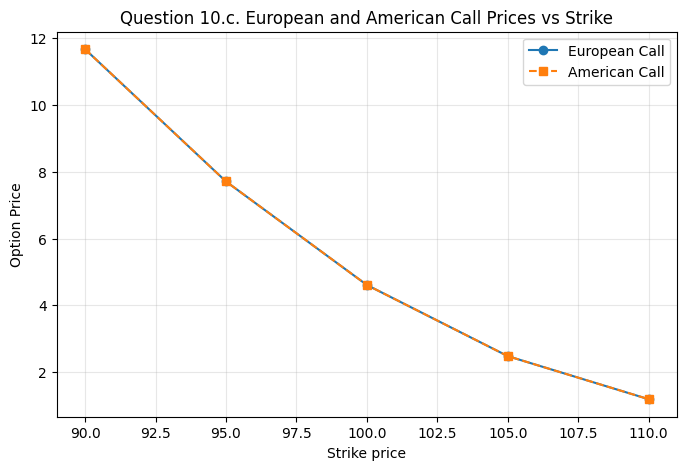

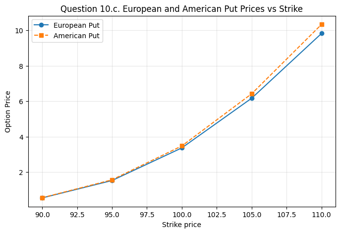

```python
def plot_(df_, type_here='Call'):
    plt.figure(figsize=(8,5))
    plt.plot(df_['Strike'], df_['European ' + type_here], marker='o',
             label='European ' + type_here)
    plt.plot(df_['Strike'], df_['American ' + type_here], marker='s',
             linestyle='--',
             label='American ' + type_here)
    plt.xlabel('Strike price')
    plt.ylabel('Option Price')
    plt.title(
        f'Question 10.c. European and American {type_here} Prices vs Strike')
    plt.legend()
    plt.grid(alpha=0.3)
    plt.show()

plot_(df_, type_here='Call')
plot_(df_, type_here='Put')
```

#### Question 11: Heston Model Pricing

```python
def heston_mc_paths(S0, v0, r, kappa, theta, xi, rho, T, n_steps, n_paths, seed=None):
    """
    Simulate Heston paths with an Euler / full-truncation scheme.
    Returns the stock-price path array (n_paths, n_steps+1) and the
    standard-normal draws used (for common-random-number reuse in Q12).
    """
    rng = np.random.default_rng(seed)
    dt = T / n_steps

    Z1 = rng.standard_normal((n_paths, n_steps))
    Zi = rng.standard_normal((n_paths, n_steps))
    Z2 = rho * Z1 + np.sqrt(1 - rho ** 2) * Zi   # correlated with Z1

    S = np.empty((n_paths, n_steps + 1))
    v = np.empty((n_paths, n_steps + 1))
    S[:, 0] = S0
    v[:, 0] = v0

    for t in range(n_steps):
        v_pos = np.maximum(v[:, t], 0.0)
        S[:, t + 1] = S[:, t] * np.exp((r - 0.5 * v_pos) * dt + np.sqrt(v_pos * dt) * Z1[:, t])
        v[:, t + 1] = v[:, t] + kappa * (theta - v_pos) * dt + xi * np.sqrt(v_pos * dt) * Z2[:, t]

    return S, (Z1, Zi)


def heston_price(S0, K, v0, r, kappa, theta, xi, rho, T, n_steps=100, n_paths=100_000,
                  option_type='call', seed=None):
    S, draws = heston_mc_paths(S0, v0, r, kappa, theta, xi, rho, T, n_steps, n_paths, seed)
    ST = S[:, -1]
    payoff = np.maximum(ST - K, 0.0) if option_type == 'call' else np.maximum(K - ST, 0.0)
    disc_payoff = np.exp(-r * T) * payoff
    price = disc_payoff.mean()
    stderr = disc_payoff.std(ddof=1) / np.sqrt(n_paths)
    return price, stderr, draws
```

```python
# ============================================================
# QUESTION 11 — HESTON MODEL: ATM CALL AND PUT PRICING
# ============================================================

import numpy as np
import pandas as pd
from math import erf, sqrt, exp, log

# -------------------------
# Step 1: Model parameters
# -------------------------

S0 = 100.0
K = 100.0
r = 0.05
T = 0.25
sigma = 0.20

# Heston parameters
v0 = 0.04
kappa = 1.85
theta = 0.04
xi = 0.35

n_steps = 100
n_paths = 100_000
seed = 42


# ============================================================
# Black-Scholes benchmark
# ============================================================

def norm_cdf(x):
    return 0.5 * (1.0 + erf(x / sqrt(2.0)))


def black_scholes_price(S0, K, r, sigma, T, option_type='call'):

    d1 = (log(S0 / K) + (r + 0.5 * sigma**2) * T) / (sigma * sqrt(T))
    d2 = d1 - sigma * sqrt(T)

    if option_type == 'call':
        price = S0 * norm_cdf(d1) - K * exp(-r * T) * norm_cdf(d2)
    else:
        price = K * exp(-r * T) * norm_cdf(-d2) - S0 * norm_cdf(-d1)

    return price


# Constant-volatility benchmark
bs_call = black_scholes_price(
    S0, K, r, sigma, T, option_type='call'
)

bs_put = black_scholes_price(
    S0, K, r, sigma, T, option_type='put'
)


# ============================================================
# Heston prices for rho = -0.30 and rho = -0.70
# ============================================================

results_q11 = []

for rho in [-0.30, -0.70]:

    # Call
    call_price, call_se, _ = heston_price(
        S0=S0,
        K=K,
        v0=v0,
        r=r,
        kappa=kappa,
        theta=theta,
        xi=xi,
        rho=rho,
        T=T,
        n_steps=n_steps,
        n_paths=n_paths,
        option_type='call',
        seed=seed
    )

    # Put
    put_price, put_se, _ = heston_price(
        S0=S0,
        K=K,
        v0=v0,
        r=r,
        kappa=kappa,
        theta=theta,
        xi=xi,
        rho=rho,
        T=T,
        n_steps=n_steps,
        n_paths=n_paths,
        option_type='put',
        seed=seed
    )

    results_q11.append({
        'Model': 'Heston',
        'rho': rho,
        'Call Price': call_price,
        'Put Price': put_price,
        'Call SE': call_se,
        'Put SE': put_se,
        'Call Difference vs BS': call_price - bs_call,
        'Put Difference vs BS': put_price - bs_put
    })


# Add Black-Scholes benchmark
results_q11.append({
    'Model': 'Black-Scholes',
    'rho': 'N/A',
    'Call Price': bs_call,
    'Put Price': bs_put,
    'Call SE': np.nan,
    'Put SE': np.nan,
    'Call Difference vs BS': 0.0,
    'Put Difference vs BS': 0.0
})


# Create DataFrame
df_q11 = pd.DataFrame(results_q11)


# ============================================================
# Display results
# ============================================================

print("============================================================")
print("QUESTION 11 — HESTON MODEL PRICING")
print("============================================================")

print(
    df_q11.to_string(
        index=False,
        formatters={
            'Call Price': lambda x: f'{x:.4f}',
            'Put Price': lambda x: f'{x:.4f}',
            'Call SE': lambda x: f'{x:.6f}' if not np.isnan(x) else 'N/A',
            'Put SE': lambda x: f'{x:.6f}' if not np.isnan(x) else 'N/A',
            'Call Difference vs BS': lambda x: f'{x:.4f}',
            'Put Difference vs BS': lambda x: f'{x:.4f}'
        }
    )
)
```

```
============================================================
QUESTION 11 — HESTON MODEL PRICING
============================================================
        Model     rho Call Price Put Price  Call SE   Put SE Call Difference vs BS Put Difference vs BS
       Heston -0.3000     4.5569    3.3056 0.019731 0.017244               -0.0581              -0.0672
       Heston -0.7000     4.5787    3.3322 0.017754 0.018438               -0.0363              -0.0406
Black-Scholes     N/A     4.6150    3.3728      NaN      NaN                0.0000               0.0000
```

#### Question 12: Delta and Gamma

For Q12, we're going to use the numerical finite-difference method suggested in the question.

For each Heston correlation, we calculate:

$$ \Delta \approx \frac{V(S+h)-V(S-h)}{2h} $$

```python
# ============================================================
# QUESTION 12 — HESTON DELTA AND GAMMA
# ============================================================

# Small stock-price bump
h = 0.10

results_q12 = []


# ============================================================
# Numerical Greeks for each correlation
# ============================================================

for rho in [-0.30, -0.70]:

    # --------------------------------------------------------
    # Call prices at S0-h, S0, S0+h
    # --------------------------------------------------------

    call_down, _, _ = heston_price(
        S0=S0 - h,
        K=K,
        v0=v0,
        r=r,
        kappa=kappa,
        theta=theta,
        xi=xi,
        rho=rho,
        T=T,
        n_steps=n_steps,
        n_paths=n_paths,
        option_type='call',
        seed=seed
    )

    call_mid, _, _ = heston_price(
        S0=S0,
        K=K,
        v0=v0,
        r=r,
        kappa=kappa,
        theta=theta,
        xi=xi,
        rho=rho,
        T=T,
        n_steps=n_steps,
        n_paths=n_paths,
        option_type='call',
        seed=seed
    )

    call_up, _, _ = heston_price(
        S0=S0 + h,
        K=K,
        v0=v0,
        r=r,
        kappa=kappa,
        theta=theta,
        xi=xi,
        rho=rho,
        T=T,
        n_steps=n_steps,
        n_paths=n_paths,
        option_type='call',
        seed=seed
    )


    # --------------------------------------------------------
    # Call Delta and Gamma
    # --------------------------------------------------------

    call_delta = (call_up - call_down) / (2 * h)

    call_gamma = (
        call_up - 2 * call_mid + call_down
    ) / (h ** 2)


    # --------------------------------------------------------
    # Put prices at S0-h, S0, S0+h
    # --------------------------------------------------------

    put_down, _, _ = heston_price(
        S0=S0 - h,
        K=K,
        v0=v0,
        r=r,
        kappa=kappa,
        theta=theta,
        xi=xi,
        rho=rho,
        T=T,
        n_steps=n_steps,
        n_paths=n_paths,
        option_type='put',
        seed=seed
    )

    put_mid, _, _ = heston_price(
        S0=S0,
        K=K,
        v0=v0,
        r=r,
        kappa=kappa,
        theta=theta,
        xi=xi,
        rho=rho,
        T=T,
        n_steps=n_steps,
        n_paths=n_paths,
        option_type='put',
        seed=seed
    )

    put_up, _, _ = heston_price(
        S0=S0 + h,
        K=K,
        v0=v0,
        r=r,
        kappa=kappa,
        theta=theta,
        xi=xi,
        rho=rho,
        T=T,
        n_steps=n_steps,
        n_paths=n_paths,
        option_type='put',
        seed=seed
    )


    # --------------------------------------------------------
    # Put Delta and Gamma
    # --------------------------------------------------------

    put_delta = (put_up - put_down) / (2 * h)

    put_gamma = (
        put_up - 2 * put_mid + put_down
    ) / (h ** 2)


    # --------------------------------------------------------
    # Store results
    # --------------------------------------------------------

    results_q12.append({
        'Model': 'Heston',
        'rho': rho,
        'Call Delta': call_delta,
        'Call Gamma': call_gamma,
        'Put Delta': put_delta,
        'Put Gamma': put_gamma
    })


# ============================================================
# Display results
# ============================================================

df_q12 = pd.DataFrame(results_q12)

print()
print("============================================================")
print("QUESTION 12 — HESTON DELTA AND GAMMA")
print("============================================================")

print(
    df_q12.to_string(
        index=False,
        formatters={
            'Call Delta': lambda x: f'{x:.6f}',
            'Call Gamma': lambda x: f'{x:.6f}',
            'Put Delta': lambda x: f'{x:.6f}',
            'Put Gamma': lambda x: f'{x:.6f}'
        }
    )
)
```

```
============================================================
QUESTION 12 — HESTON DELTA AND GAMMA
============================================================
 Model     rho Call Delta Call Gamma Put Delta Put Gamma
Heston -0.3000   0.594277   0.040917 -0.405814  0.040917
Heston -0.7000   0.622103   0.038205 -0.377940  0.038205
```

**Comment.** Because $v_0=\theta=0.04$ matches the Step-1 baseline vol, the ATM Heston call and put prices land close to the Step-1 binomial/Black-Scholes prices for both correlations, as expected: ATM option value is driven mostly by average variance over the option's life. Any small residual gap is Monte-Carlo noise (see the standard errors) plus a modest convexity effect from stochastic volatility.